# Dissertation Analysis: Correlations - Collection Rate (Team) - Team Orientation

Jamiahus Walton

2019-06-29

# Motivation

The motivation behind this analysis is to discover different correlations between team’s actual performance and participants perception of team performance.

**Note:** The corect item collection time variaable’s units is Sec per item. A high performing team will have a lower value and low performing team will have a higher value.

# Is there correlation between a actual performance (i.e., Collection Rate) and self-reported performance (i.e, Performance (reverse) from TLX)?

## Collection Rate - Collection_rate_correct_item_team

### Plots and Stats

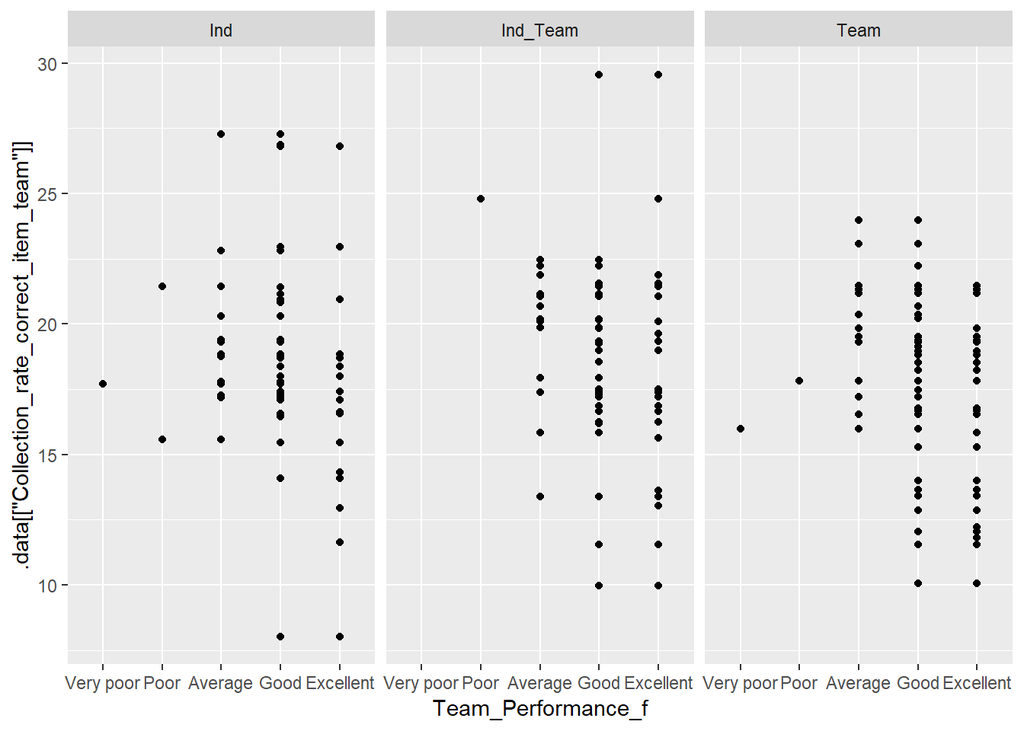

```r
plot_data_ind <- ind_data %>%
  select(Team_Performance,
         params$dependent_response_team,
         Target) %>%
  mutate(Team_Performance_f = factor(.data[["Team_Performance"]], levels = c("Very poor", "Poor", "Average", "Good", "Excellent"))) # This mutate column was generated to order the facet groups.

ggplot(data = plot_data_ind, aes(x = Team_Performance_f, y = .data[[params$dependent_response_team]])) +
  geom_point() +
  facet_grid( . ~ Target)
```

No obious patterns. No obvious violation of monotonic relationship.

```r
for (my_target in c("Ind", "Team", "Ind_Team")) {
  plot_data_ind <- ind_data %>%
    select(Team_Performance,
         params$dependent_response_team,
         Target) %>%
    mutate(Team_Performance_f = factor(.data[["Team_Performance"]], levels = c("Very poor", "Poor", "Average", "Good", "Excellent"))) %>% # This mutate column was generated to order the facet groups. This needed because this puts this factor in order from smallest to greatest. I expect a pattern to occur when moving from smallest (1 - Very Poor) to greatest (5 - Excellent)
    filter(Target == my_target)

  N_paris<- length(plot_data_ind[[params$dependent_response_team]])

  print(paste("Correltation: Condition =", my_target))
  print(paste("Pairs:", N_paris))

  print(cor.test(y = plot_data_ind[[params$dependent_response_team]], x = as.numeric(plot_data_ind[["Team_Performance_f"]]), method = "kendall"))
}
```

```
## [1] "Correltation: Condition = Ind"
## [1] "Pairs: 117"
##
##  Kendall's rank correlation tau
##
## data:  as.numeric(plot_data_ind[["Team_Performance_f"]]) and plot_data_ind[[params$dependent_response_team]]
## z = -3.8437, p-value = 0.0001212
## alternative hypothesis: true tau is not equal to 0
## sample estimates:
##       tau
## -0.278891
##
## [1] "Correltation: Condition = Team"
## [1] "Pairs: 117"
##
##  Kendall's rank correlation tau
##
## data:  as.numeric(plot_data_ind[["Team_Performance_f"]]) and plot_data_ind[[params$dependent_response_team]]
## z = -4.4903, p-value = 7.112e-06
## alternative hypothesis: true tau is not equal to 0
## sample estimates:
##        tau
## -0.3282895
##
## [1] "Correltation: Condition = Ind_Team"
## [1] "Pairs: 117"
##
##  Kendall's rank correlation tau
##
## data:  as.numeric(plot_data_ind[["Team_Performance_f"]]) and plot_data_ind[[params$dependent_response_team]]
## z = -2.7914, p-value = 0.005248
## alternative hypothesis: true tau is not equal to 0
## sample estimates:
##        tau
## -0.2038097
```

When grouping paired responses for correct collection rate and performance (reverse) by Target, the results showed a **significant** negative correlation for Ind ($\tau_b = -0.278891$), Team($\tau_b = -0.3282895$), and IaT($\tau_b = -0.2038097$), indicating a correct perception of team performance.

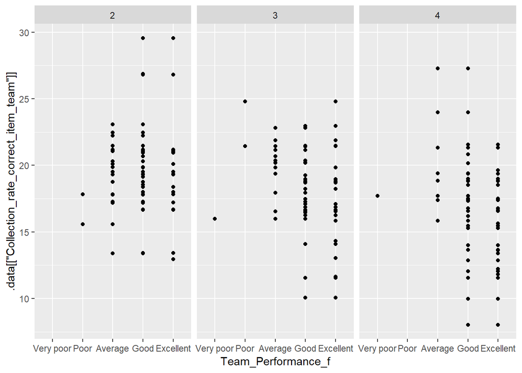

```r
plot_data_ind <- ind_data %>%
  select(Team_Performance,
         params$dependent_response_team,
         SessionOrder) %>%
  mutate(Team_Performance_f = factor(.data[["Team_Performance"]], levels = c("Very poor", "Poor", "Average", "Good", "Excellent"))) # This mutate column was generated to order the facet groups.

ggplot(data = plot_data_ind, aes(x = Team_Performance_f, y = .data[[params$dependent_response_team]])) +
  geom_point() +
  facet_grid( . ~ SessionOrder)
```

No obvious violation of monotonic relationship.

```r
for (my_session in c(2:4)) {
  plot_data_ind <- ind_data %>%
    select(Team_Performance,
           params$dependent_response_team,
           SessionOrder) %>%
    mutate(Team_Performance_f = factor(.data[["Team_Performance"]], levels = c("Very poor", "Poor", "Average", "Good", "Excellent"))) %>% # This mutate column was generated to order the facet groups.
    filter(SessionOrder == my_session)

  N_paris<- length(plot_data_ind[[params$dependent_response_team]])

  print(paste("Correltation: Session =", my_session))
  print(paste("Pairs:", N_paris))

  print(cor.test(y = plot_data_ind[[params$dependent_response_team]], x = as.numeric(plot_data_ind[["Team_Performance_f"]]), method = "kendall"))
}
```

```
## [1] "Correltation: Session = 2"
## [1] "Pairs: 117"
##
##  Kendall's rank correlation tau
##
## data:  as.numeric(plot_data_ind[["Team_Performance_f"]]) and plot_data_ind[[params$dependent_response_team]]
## z = -0.55895, p-value = 0.5762
## alternative hypothesis: true tau is not equal to 0
## sample estimates:
##         tau
## -0.04074167
##
## [1] "Correltation: Session = 3"
## [1] "Pairs: 117"
##
##  Kendall's rank correlation tau
##
## data:  as.numeric(plot_data_ind[["Team_Performance_f"]]) and plot_data_ind[[params$dependent_response_team]]
## z = -3.6695, p-value = 0.000243
## alternative hypothesis: true tau is not equal to 0
## sample estimates:
##        tau
## -0.2662358
##
## [1] "Correltation: Session = 4"
## [1] "Pairs: 117"
##
##  Kendall's rank correlation tau
##
## data:  as.numeric(plot_data_ind[["Team_Performance_f"]]) and plot_data_ind[[params$dependent_response_team]]
## z = -4.4565, p-value = 8.331e-06
## alternative hypothesis: true tau is not equal to 0
## sample estimates:
##        tau
## -0.3303187
```

When grouping paired responses for correct collection rate and performance (reverse) by session order, the results showed a **significant** negative correlation in session 3 ($_b = -0.2662358 $) and 4 ($_b = -0.3303187$).

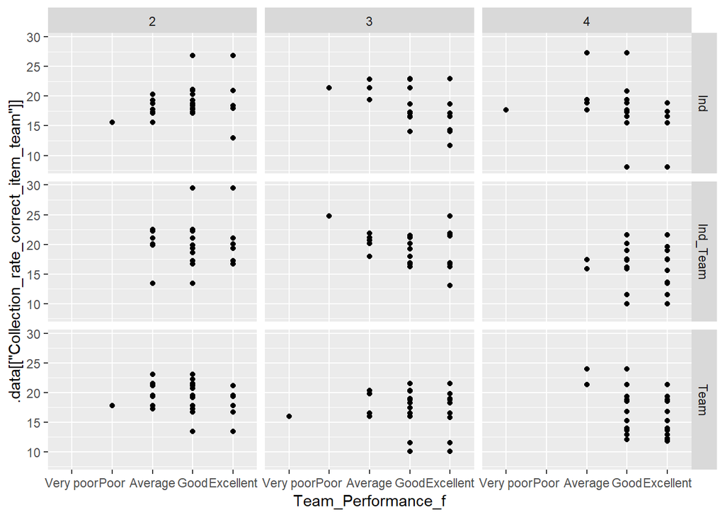

```r
plot_data_ind <- ind_data %>%
  select(Team_Performance,
         params$dependent_response_team,
         Target,
         SessionOrder) %>%
  mutate(Team_Performance_f = factor(.data[["Team_Performance"]], levels = c("Very poor", "Poor", "Average", "Good", "Excellent"))) # This mutate column was generated to order the facet groups.

ggplot(data = plot_data_ind, aes(x = Team_Performance_f, y = .data[[params$dependent_response_team]])) +
  geom_point() +
  facet_grid( Target ~ SessionOrder)
```

No obvious violation of monotonic relationship.

```r
for (my_session in c(2:4)) {
  for (my_target in c("Ind", "Team", "Ind_Team")) {
    plot_data_ind <- ind_data %>%
      select(Team_Performance,
             params$dependent_response_team,
             Target,
             SessionOrder) %>%
      mutate(Team_Performance_f = factor(.data[["Team_Performance"]], levels = c("Very poor", "Poor", "Average", "Good", "Excellent"))) %>% # This mutate column was generated to order the facet groups.
      filter(Target == my_target, SessionOrder == my_session)

    N_paris<- length(plot_data_ind[[params$dependent_response_team]])

    test<- cor.test(y = plot_data_ind[[params$dependent_response_team]], x = as.numeric(plot_data_ind[["Team_Performance_f"]]), method = "kendall")

    if(test$p.value < 0.1){
      print(paste("Correltation: Condition =", my_target,",", "Session =", my_session))
      print(paste("Pairs:", N_paris))
    }
    print(test$p.value)
  }
}
```

```
## [1] 0.2985816
```

```
## [1] "Correltation: Condition = Team , Session = 2"
## [1] "Pairs: 39"
## [1] 0.08990593
```

```
## [1] 0.444449
```

```
## [1] "Correltation: Condition = Ind , Session = 3"
## [1] "Pairs: 39"
## [1] 4.891505e-05
```

```
## [1] 0.2464371
```

```
## [1] 0.3356415
```

```
## [1] "Correltation: Condition = Ind , Session = 4"
## [1] "Pairs: 36"
## [1] 0.004635178
```

```
## [1] "Correltation: Condition = Team , Session = 4"
## [1] "Pairs: 39"
## [1] 0.0007390154
```

```
## [1] 0.195602
```

There was a **significant** correltation in the following condition and session combinations: Condition = Ind , Session = 3 Condition = Ind , Session = 4 Condition = Team , Session = 4

There was a **marginally significant** correlation in the folloing condition and session: Condition = Team , Session = 2

```r
my_target<- "Ind"
my_session<- 3

plot_data_ind <- ind_data %>%
  select(Team_Performance,
         params$dependent_response_team,
         Target,
         SessionOrder) %>%
  mutate(Team_Performance_f = factor(.data[["Team_Performance"]], levels = c("Very poor", "Poor", "Average", "Good", "Excellent"))) %>% # This mutate column was generated to order the facet groups.
  filter(Target == my_target, SessionOrder == my_session)

N_paris<- length(plot_data_ind[[params$dependent_response_team]])

test<- cor.test(y = plot_data_ind[[params$dependent_response_team]], x = as.numeric(plot_data_ind[["Team_Performance_f"]]), method = "kendall")
if(test$p.value < 0.1){
  print(paste("Correltation: Condition =", my_target,",", "Session =", my_session))
  print(paste("Pairs:", N_paris))
}
```

```
## [1] "Correltation: Condition = Ind , Session = 3"
## [1] "Pairs: 39"
```

```r
print(test)
```

```
##
##  Kendall's rank correlation tau
##
## data:  as.numeric(plot_data_ind[["Team_Performance_f"]]) and plot_data_ind[[params$dependent_response_team]]
## z = -4.0608, p-value = 4.892e-05
## alternative hypothesis: true tau is not equal to 0
## sample estimates:
##        tau
## -0.5273944
```

```r
#----
my_target<- "Ind"
my_session<- 4

plot_data_ind <- ind_data %>%
  select(Team_Performance,
         params$dependent_response_team,
         Target,
         SessionOrder) %>%
  mutate(Team_Performance_f = factor(.data[["Team_Performance"]], levels = c("Very poor", "Poor", "Average", "Good", "Excellent"))) %>% # This mutate column was generated to order the facet groups.
  filter(Target == my_target, SessionOrder == my_session)

N_paris<- length(plot_data_ind[[params$dependent_response_team]])

test<- cor.test(y = plot_data_ind[[params$dependent_response_team]], x = as.numeric(plot_data_ind[["Team_Performance_f"]]), method = "kendall")
if(test$p.value < 0.1){
  print(paste("Correltation: Condition =", my_target,",", "Session =", my_session))
  print(paste("Pairs:", N_paris))
}
```

```
## [1] "Correltation: Condition = Ind , Session = 4"
## [1] "Pairs: 36"
```

```r
print(test)
```

```
##
##  Kendall's rank correlation tau
##
## data:  as.numeric(plot_data_ind[["Team_Performance_f"]]) and plot_data_ind[[params$dependent_response_team]]
## z = -2.8314, p-value = 0.004635
## alternative hypothesis: true tau is not equal to 0
## sample estimates:
##        tau
## -0.3865452
```

```r
#----
my_target<- "Team"
my_session<- 4

plot_data_ind <- ind_data %>%
  select(Team_Performance,
         params$dependent_response_team,
         Target,
         SessionOrder) %>%
  mutate(Team_Performance_f = factor(.data[["Team_Performance"]], levels = c("Very poor", "Poor", "Average", "Good", "Excellent"))) %>% # This mutate column was generated to order the facet groups.
  filter(Target == my_target, SessionOrder == my_session)

N_paris<- length(plot_data_ind[[params$dependent_response_team]])

test<- cor.test(y = plot_data_ind[[params$dependent_response_team]], x = as.numeric(plot_data_ind[["Team_Performance_f"]]), method = "kendall")
if(test$p.value < 0.1){
  print(paste("Correltation: Condition =", my_target,",", "Session =", my_session))
  print(paste("Pairs:", N_paris))
}
```

```
## [1] "Correltation: Condition = Team , Session = 4"
## [1] "Pairs: 39"
```

```r
print(test)
```

```
##
##  Kendall's rank correlation tau
##
## data:  as.numeric(plot_data_ind[["Team_Performance_f"]]) and plot_data_ind[[params$dependent_response_team]]
## z = -3.3747, p-value = 0.000739
## alternative hypothesis: true tau is not equal to 0
## sample estimates:
##        tau
## -0.4506159
```

```r
#----
my_target<- "Team"
my_session<- 2

plot_data_ind <- ind_data %>%
  select(Team_Performance,
         params$dependent_response_team,
         Target,
         SessionOrder) %>%
  mutate(Team_Performance_f = factor(.data[["Team_Performance"]], levels = c("Very poor", "Poor", "Average", "Good", "Excellent"))) %>% # This mutate column was generated to order the facet groups.
  filter(Target == my_target, SessionOrder == my_session)

N_paris<- length(plot_data_ind[[params$dependent_response_team]])

test<- cor.test(y = plot_data_ind[[params$dependent_response_team]], x = as.numeric(plot_data_ind[["Team_Performance_f"]]), method = "kendall")
if(test$p.value < 0.1){
  print(paste("Correltation: Condition =", my_target,",", "Session =", my_session))
  print(paste("Pairs:", N_paris))
}
```

```
## [1] "Correltation: Condition = Team , Session = 2"
## [1] "Pairs: 39"
```

```r
print(test)
```

```
##
##  Kendall's rank correlation tau
##
## data:  as.numeric(plot_data_ind[["Team_Performance_f"]]) and plot_data_ind[[params$dependent_response_team]]
## z = -1.6959, p-value = 0.08991
## alternative hypothesis: true tau is not equal to 0
## sample estimates:
##        tau
## -0.2215666
```

When grouping paired responses for correct collection rate and performance (reverse) by target and session order, the results showed a **significant** negative correlation in Ind in session 3 ($\tau_b = -0.5273944$), in Ind in session 4 ($_b = -0.3865452 $), and Team in session 4 ($_b = -0.4506159$). The results showed a __marginally signifcant__ negative correlation in Team in session 2 ($_b = -0.2215666$).

## Summary

“When grouping paired responses for correct collection rate and performance (reverse) by Target, the results showed a **significant** negative correlation for Ind ($\tau_b = -0.278891$), Team($\tau_b = -0.3282895$), and IaT($\tau_b = -0.2038097$), indicating a correct perception of team performance.”

"When grouping paired responses for correct collection rate and performance (reverse) by session order, the results showed a **significant** negative correlation in session 3 ($_b = -0.2662358 $) and 4 ($_b = -0.3303187$)."

"When grouping paired responses for correct collection rate and performance (reverse) by target and session order, the results showed a **significant** negative correlation in Ind in session 3 ($\tau_b = -0.5273944$), in Ind in session 4 ($_b = -0.3865452 $), and Team in session 4 ($_b = -0.4506159$). The results showed a __marginally signifcant__ negative correlation in Team in session 2 ($_b = -0.2215666$)."